# Mile Stone Report

Marco Venturi

2022-09-25

## Abstarct

The milestone project has goal to retrieve, clean analize and visualize data for understand how we can predict the next word while a user is typing by a mobile keyboard. At the end of this Report we will understand the summary statistics that influence the possible prediction and how words can be well represented over n-grams too.

## Data

The data made available by Jhon Hopkins University’s coursera project and can be retrive [here](https://d396qusza40orc.cloudfront.net/dsscapstone/dataset/Coursera-SwiftKey.zip).

I will focus on using english language files only.

```r
blogs <- readLines("./final/en_US/en_US.blogs.txt", warn = FALSE, encoding = "UTF-8", skipNul = TRUE)
news <- readLines("./final/en_US/en_US.news.txt", warn = FALSE, encoding = "UTF-8", skipNul = TRUE)
twitter <- readLines("./final/en_US/en_US.twitter.txt", warn = FALSE, encoding = "UTF-8", skipNul = TRUE)
```

### Generation of Statistics Summary

Observing file size, lines and size type(small, medium, large).

```r
 stats <- data.frame(
        FileName = c("blogs", "news", "twitter"),
        FileSize = sapply(list(blogs, news, twitter), function(x){format(object.size(x), "MB")}),
        t(rbind(sapply(list(blogs, news, twitter), stri_stats_general),
        Words = sapply(list(blogs, news, twitter), stri_stats_latex)[4,]))
)

stats
```

```
##   FileName FileSize   Lines LinesNEmpty     Chars CharsNWhite    Words
## 1    blogs 255.4 Mb  899288      899288 206824382   170389539 37570839
## 2     news  19.8 Mb   77259       77259  15639408    13072698  2651432
## 3  twitter   319 Mb 2360148     2360148 162096241   134082806 30451170
```

### Sampling Data

The data results too large for a complete use, so i will subset the data in three new dataset that will represent just the 1% of datasets.

```r
set.seed(1234)
sampleSize <- 0.01

blogsSub <- sample(blogs, length(blogs) * sampleSize)
newsSub <- sample(news, length(news) * sampleSize)
twitterSub <- sample(twitter, length(twitter) * sampleSize)

sampleData <- c(blogsSub, newsSub, twitterSub)

sampleStats <- data.frame(
        FileName = c("blogsSub", "newsSub", "twitterSub", "sampleData"),
        FileSize = sapply(list(blogsSub, newsSub, twitterSub, sampleData), function(x){format(object.size(x), "MB")}),
        t(rbind(sapply(list(blogsSub, newsSub, twitterSub, sampleData), stri_stats_general),
        Words = sapply(list(blogsSub, newsSub, twitterSub, sampleData), stri_stats_latex)[4,])
        )
)

sampleStats
```

```
##     FileName FileSize Lines LinesNEmpty   Chars CharsNWhite  Words
## 1   blogsSub   2.6 Mb  8992        8992 2068110     1703458 377158
## 2    newsSub   0.2 Mb   772         772  156344      130606  26624
## 3 twitterSub   3.2 Mb 23601       23601 1620028     1340155 303982
## 4 sampleData     6 Mb 33365       33365 3844482     3174219 707764
```

## Features Extraction

Building corpus and check the size.

```r
corpus <- VCorpus(VectorSource(sampleData))
format(object.size(corpus), "MB")
```

```
## [1] "137.3 Mb"
```

The VCorpus result be 137.3 MB, quite large even whit a sample size of 1% . This maybe be an issue due to memory constraints when it comes to build the predictive model, but right now i will start from here for observe where this choice will lead me.

In this stage there will be no manage of stop words, because is too early for understand the impact of them in this specific case respect to a stage project where i already have results over a predictive model, so stop words will be discuss before finalizing the application.

```r
cleanCorpus <- corpus %>%
       tm_map(content_transformer(tolower)) %>% # Convert all to lower case
       tm_map(removePunctuation) %>% # Remove punctuation marks
       tm_map(removeNumbers) %>% # Remove numbers
       tm_map(stripWhitespace) %>% # Remove whitespace
       tm_map(PlainTextDocument) # Convert all to plain text document
```

### Tokenize and Construct the N-Grams

This step will observe unigram, bigram and trigram matrix, for understand the frequency of different words situation.

```r
uniTokenizer <- function(x) NGramTokenizer(x, Weka_control(min = 1, max = 1))
biTokenizer <- function(x) NGramTokenizer(x, Weka_control(min = 2, max = 2))
triTokenizer <- function(x) NGramTokenizer(x, Weka_control(min = 3, max = 3))

uniMatrix <- TermDocumentMatrix(cleanCorpus, control = list(tokenize = uniTokenizer))
biMatrix <- TermDocumentMatrix(cleanCorpus, control = list(tokenize = biTokenizer))
triMatrix <- TermDocumentMatrix(cleanCorpus, control = list(tokenize = triTokenizer))
```

### Calculate the Frequencies of the N-Grams

Frequency of N-grams.

```r
uniCorpus <- findFreqTerms(uniMatrix, lowfreq = 20)
biCorpus <- findFreqTerms(biMatrix, lowfreq = 20)
triCorpus <- findFreqTerms(triMatrix, lowfreq = 20)

#unicorpus
uniCorpusFreq <- rowSums(as.matrix(uniMatrix[uniCorpus,]))
uniCorpusFreq <- data.frame(word = names(uniCorpusFreq), frequency = uniCorpusFreq)
uniCorpusFreq <- arrange(uniCorpusFreq, desc(frequency))
head(uniCorpusFreq)
```

```
##      word frequency
## the   the     29452
## and   and     15680
## you   you      8380
## for   for      7723
## that that      7125
## with with      4778
```

```r
#bicorpus
biCorpusFreq <- rowSums(as.matrix(biMatrix[biCorpus,]))
biCorpusFreq <- data.frame(word = names(biCorpusFreq), frequency = biCorpusFreq)
biCorpusFreq <- arrange(biCorpusFreq, desc(frequency))
head(biCorpusFreq)
```

```
##            word frequency
## of the   of the      2543
## in the   in the      2491
## for the for the      1436
## on the   on the      1290
## to the   to the      1287
## to be     to be      1213
```

```r
#tricorpus
triCorpusFreq <- rowSums(as.matrix(triMatrix[triCorpus,]))
triCorpusFreq <- data.frame(word = names(triCorpusFreq), frequency = triCorpusFreq)
triCorpusFreq <- arrange(triCorpusFreq, desc(frequency))
head(triCorpusFreq)
```

```
##                                  word frequency
## thanks for the         thanks for the       243
## one of the                 one of the       239
## a lot of                     a lot of       202
## going to be               going to be       149
## to be a                       to be a       131
## looking forward to looking forward to       120
```

## Data Visualization

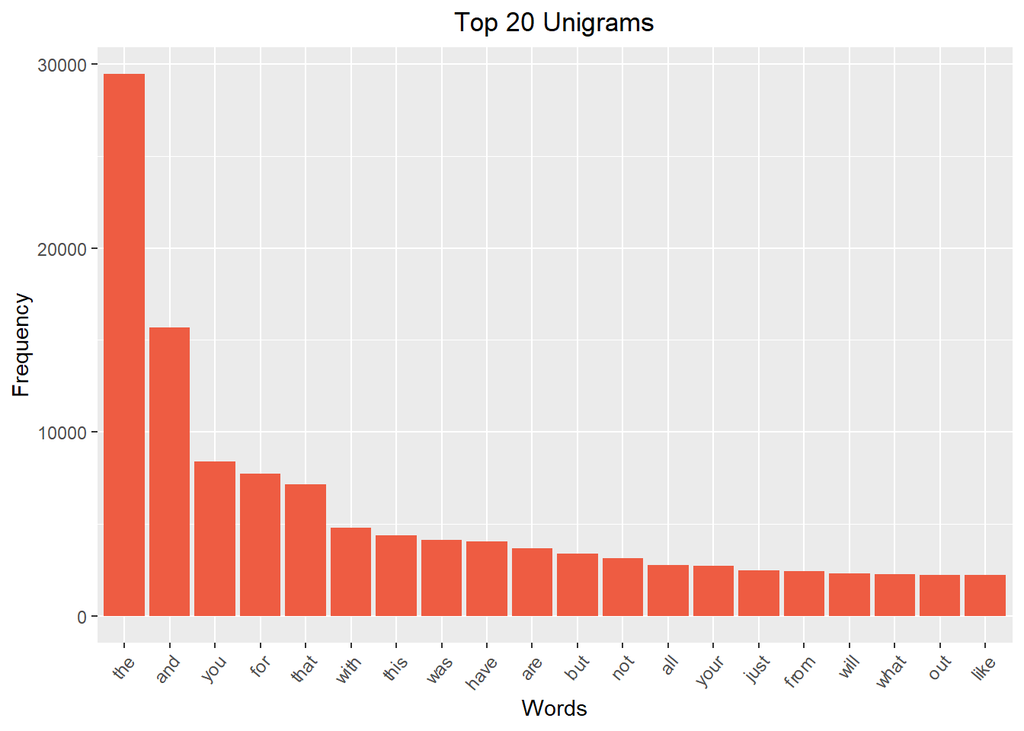

```r
uniBar <- ggplot(data = uniCorpusFreq[1:20,], aes(x = reorder(word, -frequency), y = frequency)) +
        geom_bar(stat = "identity", fill = "tomato2") +
        xlab("Words") +
        ylab("Frequency") +
        ggtitle(paste("Top 20 Unigrams")) +
        theme(plot.title = element_text(hjust = 0.5)) +
        theme(axis.text.x = element_text(angle = 50, hjust = 1))
biBar <- ggplot(data = biCorpusFreq[1:20,], aes(x = reorder(word, -frequency), y = frequency)) +
        geom_bar(stat = "identity", fill = "darkgreen") +
        xlab("Words") +
        ylab("Frequency") +
        ggtitle(paste("Top 20 Bigrams")) +
        theme(plot.title = element_text(hjust = 0.5)) +
        theme(axis.text.x = element_text(angle = 50, hjust = 1))
triBar <- ggplot(data = triCorpusFreq[1:20,], aes(x = reorder(word, -frequency), y = frequency)) +
        geom_bar(stat = "identity", fill = "deepskyblue") +
        xlab("Words") +
        ylab("Frequency") +
        ggtitle(paste("Top 20 Trigrams")) +
        theme(plot.title = element_text(hjust = 0.5)) +
        theme(axis.text.x = element_text(angle = 50, hjust = 1))

uniBar
```

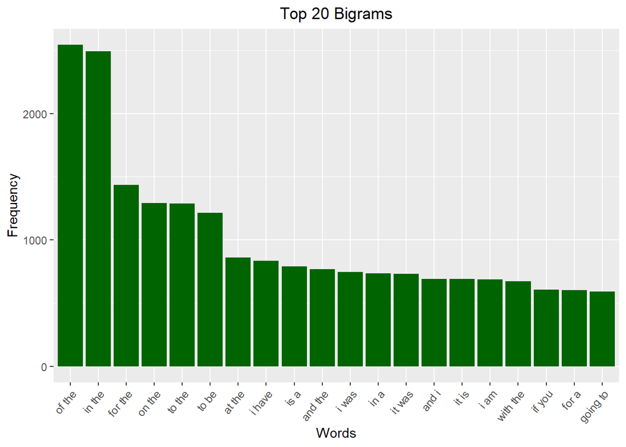

```r
biBar
```

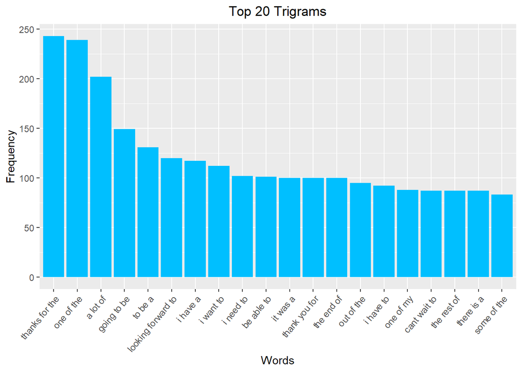

```r
triBar
```

### Words Distribution

```r
uniCorpusFreq$cum <- cumsum(uniCorpusFreq$frequency/length(uniMatrix$i))

# Number of unique words
uniMatrix$nrow
```

```
## [1] 46353
```

```r
# Number of words are needed to cover 50% of the corpora
which(uniCorpusFreq$cum >= 0.5)[1]
```

```
## [1] 158
```

```r
# Number of words are needed to cover 90% of the corpora
which(uniCorpusFreq$cum >= 0.9)[1]
```

```
## [1] 2822
```

## Summary

One question I have is whether a 1% sample of the data is enough? I may find I need to increase the sample size, but doing so could affect the performance of the application.

The VCorpus object is also quite large (137.3 Mb), even with a sample size of only 1%. This may create issues due to memory constraints when it comes time to build the predictive model.

We may need to try different sample sizes to get a balance between enough data, memory consumption and acceptable performance.

We also need to determine whether stopwords need to be removed and create a filter if profane words are suggested when a word or phrase is entered by the user.

### Next Steps

1. Build and test different prediction models and evaluate each based on their performance.
2. Make and test any necessary modifications to resolve any issues encountered during modeling.
3. Build, test and deploy a Shiny app with a simple user interface that has acceptable run time and reliably and accurately predicts the next word based on a word or phrase entered by the user.
4. Decide whether to remove the stopwords and filter out profanity, if necessary.